```python
%matplotlib inline
```

# Deep Learning Hardware and Software

# Outline

1. Deep Learning Hardware
2. Popular Frameworks and Pytorch
3. Pytorch Basics
4. Multiple Layer Perceptron (MLP) for Binary Classification
5. Online Resource

# A Workstation for Deep Learning

[figure not shown]

```
CPU RAM      | Hard Disks
SATA CARD    | Hard Disks
GPU          | Hard Disks
Power Supply | Hard Disks
```

# A Workstation for Deep Learning (Cont'd.)

- CPU: Intel (or you can pick AMD)
- RAM: Larger is better (e.g., 64GB)
- Sata Card: If you need to connect more than six HDs
- GPU: Nvidia GTX 1080 (8GB RAM)
- OS: Ubuntu 18 LTS
- Storage: Software RAID10 (other options, RAID5, RAID6, SATA RAID, Solid State Disk, etc.)

# CPU vs. GPU

[figure not shown]

Slide Credit: Fei-Fei Li, Justin Johnson, and Serena Yeung

# Computation in Context: Matrix Multiplication

[figure not shown]

Slide Credit: Fei-Fei Li, Justin Johnson, and Serena Yeung

# Programming GPUs

### CUDA (NVIDIA only)

- - Write C-like code that runs directly on the GPU
  - Higher-level APIs: cuBLAS, cuFFT, cuDNN, etc

### OpenCL

- - Similar to CUDA, but runs on anything
  - Usually slower :(

Slide Credit: Fei-Fei Li, Justin Johnson, and Serena Yeung

# CPU vs GPU in Practice

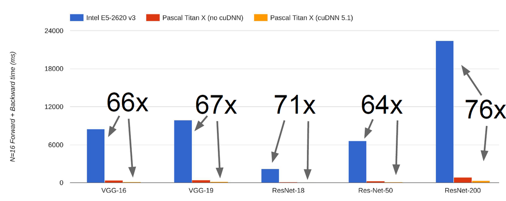

Slide Credit: Fei-Fei Li, Justin Johnson, and Serena Yeung

# CUDA Does Matter

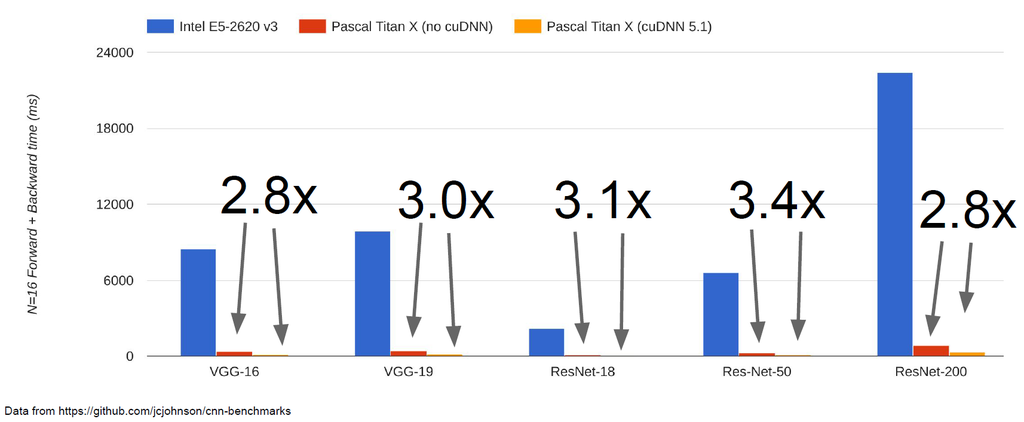

# Popular Deep Learning Frameworks

[figure not shown]

Slide Credit: Fei-Fei Li, Justin Johnson, and Serena Yeung

# Pytorch Install

### The best information source is https://pytorch.org/get-started/locally/

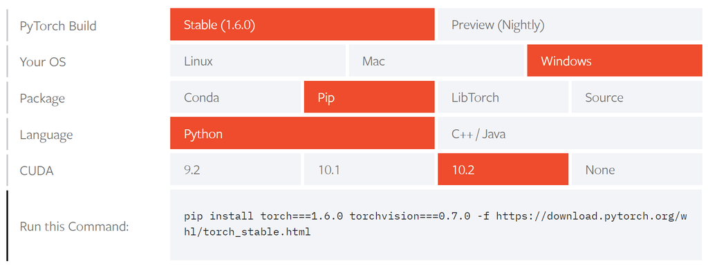

### You can do your homework without GPUs. It only takes longer to run.

# Pytorch Install Tricks

- It is common to have multiple python environments on your PC.
- To figure out which python you are using, do the following:

```python
import sys
print(sys.executable)
```

```
C:\Users\hsinminlu\WPy64-3850\python-3.8.5.amd64\python.exe
```

Before install packages via `pip`, confirm which python interpreter `pip` is using:

```python
# In Windows OS
!where.exe pip
```

```
C:\Users\hsinminlu\WPy64-3850\python-3.8.5.amd64\Scripts\pip.exe
C:\Users\hsinminlu\AppData\Local\Programs\Python\Python36\Scripts\pip.exe
C:\python27_64\Scripts\pip.exe
C:\Python27\Scripts\pip.exe
C:\Python36-32\Scripts\pip.exe
```

In Linux, use `which pip`

# Pytorch: Three Levels of Abstraction

- Tensor: Imperative ndarray, but runs on GPU
- Variable: Node in a computational graph; stores data and gradient
- Module: A neural network layer; may store state or learnable weights

# PyTorch Basics

## What is PyTorch?

It is a **replacement for NumPy** to use the power of GPUs, and a **deep learning research platform** that provides maximum flexibility and speed ([source](https://pytorch.org/tutorials/beginner/blitz/tensor_tutorial.html#sphx-glr-beginner-blitz-tensor-tutorial-py)).

You can create a [PyTorch tensor](https://pytorch.org/docs/stable/tensors.html) in a similary way that you create a NumPy ndarray:

```python
import numpy as np
import torch
print("torch version:", torch.__version__)

print('\nCreate a zero ndarray in NumPy:')
zero_np = np.zeros([2, 3])
print(zero_np)
print('\nCreate a zero tensor in PyTorch:')
zero_pt = torch.zeros([2,3])
print(zero_pt)
```

```
torch version: 1.6.0+cpu

Create a zero ndarray in NumPy:
[[0. 0. 0.]
 [0. 0. 0.]]

Create a zero tensor in PyTorch:
tensor([[0., 0., 0.],
        [0., 0., 0.]])
```

You can index into the tensor the same way you index a ndarray:

```python
print("numpy: zero_np[0,1]: {}\t(type: {})".format(str(zero_np[0,1]), type(zero_np[0,1])))
print("torch: zero_pt[0,1]: {}\t(type: {} / shape: {})".format(str(zero_pt[0,1]), type(zero_pt[0,1]), zero_pt[0,1].shape))
```

```
numpy: zero_np[0,1]: 0.0	(type: <class 'numpy.float64'>)
torch: zero_pt[0,1]: tensor(0.)	(type: <class 'torch.Tensor'> / shape: torch.Size([]))
```

Use "item()" to get a Python number from a single-valued tensor.

```python
print("       zero_pt[0,1].item(): {}\t(type: {})".format(zero_pt[0,1].item(), type(zero_pt[0,1].item())))
```

```
       zero_pt[0,1].item(): 0.0	(type: <class 'float'>)
```

A ndarray can be turned into a tensor, and vice versa:

```python
print('Turn a ndarray into a tensor with "torch.tensor()":')
zero_pt_from_np = torch.tensor(zero_np)
print(zero_pt_from_np)
print('or "torch.from_numpy():"')
zero_pt_from_np = torch.from_numpy(zero_np)
print(zero_pt_from_np)

print('\nTurn a tensor into ndarray with ".numpy()":')
zero_np_from_pt = zero_pt.numpy()
print(zero_np_from_pt)
print(type(zero_np_from_pt))
```

```
Turn a ndarray into a tensor with "torch.tensor()":
tensor([[0., 0., 0.],
        [0., 0., 0.]], dtype=torch.float64)
or "torch.from_numpy():"
tensor([[0., 0., 0.],
        [0., 0., 0.]], dtype=torch.float64)

Turn a tensor into ndarray with ".numpy()":
[[0. 0. 0.]
 [0. 0. 0.]]
<class 'numpy.ndarray'>
```

The design of PyTorch allows it to better utilize GPUs. Upon creation, a PyTorch tensor resides on the CPU. You can move a tensor across devices using `.to()`:

```python
t = torch.randn(2)
print("Initial device:\t'{}'".format(t.device))
```

```
Initial device:	'cpu'
```

If you have GPU, then you can do this:

```
t = t.to('cuda:0')
print("Move to gpu:\t'{}'".format(t.device))
```

and, you can move it back...

```
t = t.to('cpu')
print("Back to cpu:\t'{}'".format(t.device))
```

Sometimes, we need to convert the variable back to numpy:

```python
t.numpy()
```

```
array([ 0.9666123 , -0.31670862], dtype=float32)
```

# MLP Example using Breast Cancer Dataset

We demonstrate the process of constructing Multiple Layer Perception (MLP) for classification here.

The dataset is from UCI Machine Learning Repository https://archive.ics.uci.edu/ml/datasets/Breast+Cancer+Wisconsin+%28Diagnostic%29

We use the csv format from https://www.kaggle.com/uciml/breast-cancer-wisconsin-data?select=data.csv

# Data Columns

```
1) ID number
2) Diagnosis (M = malignant, B = benign)
3-32)

Ten real-valued features are computed for each cell nucleus:

a) radius (mean of distances from center to points on the perimeter)
b) texture (standard deviation of gray-scale values)
c) perimeter
d) area
e) smoothness (local variation in radius lengths)
f) compactness (perimeter^2 / area - 1.0)
g) concavity (severity of concave portions of the contour)
h) concave points (number of concave portions of the contour)
i) symmetry
j) fractal dimension ("coastline approximation" - 1)
```

# Data Preparations

```python
import pandas as pd
import numpy as np
import matplotlib.pyplot as plt
import seaborn as sns

data = pd.read_csv('deep_learning_hwsf/breast_cancer.csv');
print("\n \t The data frame has {0[0]} rows and {0[1]} columns. \n".format(data.shape))
data.info()
```

```
 	 The data frame has 569 rows and 33 columns.

<class 'pandas.core.frame.DataFrame'>
RangeIndex: 569 entries, 0 to 568
Data columns (total 33 columns):
 #   Column                   Non-Null Count  Dtype
---  ------                   --------------  -----
 0   id                       569 non-null    int64
 1   diagnosis                569 non-null    object
 2   radius_mean              569 non-null    float64
 3   texture_mean             569 non-null    float64
 4   perimeter_mean           569 non-null    float64
 5   area_mean                569 non-null    float64
 6   smoothness_mean          569 non-null    float64
 7   compactness_mean         569 non-null    float64
```

[output cut: 27 more lines]

```python
data.head(3)
```

|  | id | diagnosis | radius_mean | texture_mean | perimeter_mean | area_mean | smoothness_mean | compactness_mean | concavity_mean | concave points_mean | ... | texture_worst | perimeter_worst | area_worst | smoothness_worst | compactness_worst | concavity_worst | concave points_worst | symmetry_worst | fractal_dimension_worst | Unnamed: 32 |
| --- | --- | --- | --- | --- | --- | --- | --- | --- | --- | --- | --- | --- | --- | --- | --- | --- | --- | --- | --- | --- | --- |
| 0 | 842302 | M | 17.99 | 10.38 | 122.8 | 1001.0 | 0.11840 | 0.27760 | 0.3001 | 0.14710 | ... | 17.33 | 184.6 | 2019.0 | 0.1622 | 0.6656 | 0.7119 | 0.2654 | 0.4601 | 0.11890 | NaN |
| 1 | 842517 | M | 20.57 | 17.77 | 132.9 | 1326.0 | 0.08474 | 0.07864 | 0.0869 | 0.07017 | ... | 23.41 | 158.8 | 1956.0 | 0.1238 | 0.1866 | 0.2416 | 0.1860 | 0.2750 | 0.08902 | NaN |
| 2 | 84300903 | M | 19.69 | 21.25 | 130.0 | 1203.0 | 0.10960 | 0.15990 | 0.1974 | 0.12790 | ... | 25.53 | 152.5 | 1709.0 | 0.1444 | 0.4245 | 0.4504 | 0.2430 | 0.3613 | 0.08758 | NaN |

3 rows × 33 columns

# Drop Unwanted Columns

```python
data.drop(data.columns[[-1, 0]], axis=1, inplace=True)
data.info()
```

```
<class 'pandas.core.frame.DataFrame'>
RangeIndex: 569 entries, 0 to 568
Data columns (total 31 columns):
 #   Column                   Non-Null Count  Dtype
---  ------                   --------------  -----
 0   diagnosis                569 non-null    object
 1   radius_mean              569 non-null    float64
 2   texture_mean             569 non-null    float64
 3   perimeter_mean           569 non-null    float64
 4   area_mean                569 non-null    float64
 5   smoothness_mean          569 non-null    float64
 6   compactness_mean         569 non-null    float64
 7   concavity_mean           569 non-null    float64
 8   concave points_mean      569 non-null    float64
 9   symmetry_mean            569 non-null    float64
```

[output cut: 23 more lines]

# Number of Malignant and Benign Cases

```python
diagnosis_all = list(data.shape)[0]
diagnosis_categories = list(data['diagnosis'].value_counts())

print("The data has {} diagnosis, {} benign and {} malignant."
      .format(diagnosis_all, diagnosis_categories[0], diagnosis_categories[1]))
```

```
The data has 569 diagnosis, 357 benign and 212 malignant.
```

# Data Visualization

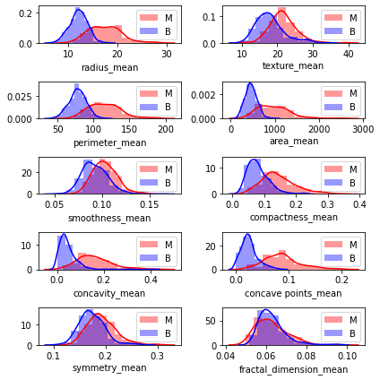

```python
features_name = list(data.columns[1:11])
bins = 12; plt.figure(figsize=(6,6))
for i, feat in enumerate(features_name):
    rows = int(len(features_name)/2)
    plt.subplot(rows, 2, i+1)
    sns.distplot(data[data['diagnosis']=='M'][feat], bins=bins, color='red', label='M')
    sns.distplot(data[data['diagnosis']=='B'][feat], bins=bins, color='blue',label='B')
    plt.legend(loc='upper right')
plt.tight_layout()
plt.show()
```

# Transform Label Values and Split Training and Test Sets

- M --> 1
- B --> 0

```python
from sklearn.model_selection import train_test_split, cross_val_score
from sklearn.metrics import accuracy_score
diag_map = {'M':1, 'B':0}
data['diagnosis'] = data['diagnosis'].map(diag_map)
X = data.loc[:,features_name]
y = data.loc[:, 'diagnosis']
# make sure we are using float32 datatype
X = X.astype('float32')
y = y.astype('float32')
X_train, X_test, y_train, y_test = train_test_split(X, y, test_size = 0.2, random_state = 42)
```

# Baseline: Random Foreast Classifier

```python
from sklearn.ensemble import RandomForestClassifier

clf = RandomForestClassifier(n_estimators = 500)
clf.fit(X_train, y_train)
prediction = clf.predict(X_test)
accuracy_rf  = accuracy_score(prediction, y_test)
print("Random Forest Accuracy: {0:.2%}".format(accuracy_rf))
```

```
Random Forest Accuracy: 94.74%
```

# Standardize Feature Values

```python
from sklearn import preprocessing
xscaler = preprocessing.StandardScaler().fit(X_train)
#standardize feature values
X_trainstd = xscaler.transform(X_train)
X_teststd = xscaler.transform(X_test)
```

```python
#Just to verify feature standardization
print("Column means:")
np.mean(X_trainstd, axis = 0)
print("Column Std.dev:")
np.std(X_trainstd, axis = 0)
```

```
Column means:
Column Std.dev:
```

```
array([1., 1., 1., 1., 1., 1., 1., 1., 1., 1.], dtype=float32)
```

# Pytorch Data Loader

- Pytorch provides built-in tools to handle data.
- You should use Pytorch Dataset and DataLoader whenever possible.
- cf. https://pytorch.org/docs/stable/data.html

Here we provide an example to develop your own dataloader.

# Define Our Dataset Objects

```python
import torch
from torch.utils import data

class Dataset(data.Dataset):
  'Characterizes a dataset for PyTorch'
  def __init__(self, Xnp, Ynp):
        'Initialization, passing Xnp and Ynp'
        self.labels = Ynp
        self.nobs = Xnp.shape[0]
        self.Xnp = Xnp
        self.Ynp = Ynp
  def __len__(self):
        'Denotes the total number of samples'
        return self.nobs
  def __getitem__(self, index):
        'Generates one sample of data'
        X = self.Xnp[index]
        y = self.Ynp[index]
        return X, y

#y_train is a pandas.core.series.Series
trainset = Dataset(X_trainstd, y_train.values)
testset = Dataset(X_teststd, y_test.values)
```

Let's verify the dataset object can function as expected.

```python
print("Get length:", len(trainset))
print("Get training data at position 3: ", trainset[3])
print("Get training data at position 3, 5, and 6: ", trainset[[3, 5, 6]])
```

```
Get length: 455
Get training data at position 3:  (array([-0.9817969 ,  1.416222  , -0.9825874 , -0.8669442 ,  0.05938998,
       -0.5967878 , -0.8202031 , -0.84511477,  0.31326434,  0.07404148],
      dtype=float32), 0.0)
Get training data at position 3, 5, and 6:  (array([[-0.9817969 ,  1.416222  , -0.9825874 , -0.8669442 ,  0.05938998,
        -0.5967878 , -0.8202031 , -0.84511477,  0.31326434,  0.07404148],
       [ 0.11958478,  1.9606553 ,  0.19953509,  0.01247319,  1.3054624 ,
         1.0661647 ,  0.9448397 ,  0.6670495 ,  1.7919351 ,  1.1126733 ],
       [ 0.08277766,  0.12788698,  0.17072272, -0.00952632, -0.58773386,
         1.220707  ,  0.5958875 ,  0.46662006, -0.35323074,  1.2723554 ]],
      dtype=float32), array([0., 1., 0.], dtype=float32))
```

# Create Dataloader

```python
trainloader = data.DataLoader(trainset, batch_size=228, shuffle=True, num_workers=0)
testloader = data.DataLoader(testset, batch_size=50, shuffle=True, num_workers=0)
```

```python
X_batch, y_batch = next(iter(trainloader))
print("X_batch size:", X_batch.size())
print("y_batch size:", y_batch.size())
```

```
X_batch size: torch.Size([228, 10])
y_batch size: torch.Size([228])
```

# Create our MLP

- Simple example (wihtout early stopping)

```python
#get number of input features
D_in = trainset.Xnp.shape[1]
H = 22
#Binary classification problem
D_out = 1
use_cuda = torch.cuda.is_available()
if use_cuda:
    device = "cuda"
else:
    device = "cpu"
print("Running on device: ", device)
net = torch.nn.Sequential(
        torch.nn.Linear(D_in, H),
        torch.nn.ReLU(),
        torch.nn.Linear(H, H),
        torch.nn.ReLU(),
        torch.nn.Linear(H, D_out),
        torch.nn.Sigmoid()
)
# convert everything to float precision.
net = net.float()
# move the model to device (i.e., cpu or gpu)
net = net.to(device)
```

```
Running on device:  cpu
```

# Define Optimizer and Loss Function

Recall that Binary Cross Entropy is: $$ \frac{1}{m} \sum_{i = 1}^{m} [y_i log{\hat{y}_i} + (1 - y_i) log{(1 - \hat{y}_i)}] $$

```python
# define the optimizer
optimizer = torch.optim.SGD(net.parameters(), lr=0.005, momentum=0.5, weight_decay = 0)
# Binary Cross Entropy Loss
loss_fn = torch.nn.BCELoss()
```

```python
nepoch = 1500
step_count = 0
log_interval = 100

for epoch_id in range(0, nepoch):
    for batch_idx, (inputs, targets) in enumerate(trainloader):
        #reshape target to two-dimensional array
        targets = targets.reshape((-1, 1))
        step_count += 1
        net.train()
        inputs, targets = inputs.to(device), targets.to(device)
        optimizer.zero_grad()
        outputs = net(inputs)
        loss = loss_fn(outputs, targets)
        loss.backward()
        optimizer.step()
        if step_count % log_interval == 0:
            print("Epoch %d Step %d Loss = %.3f (minibatch size = %d)" % (epoch_id, step_count, loss.item(), len(targets)))
```

```
Epoch 49 Step 100 Loss = 0.603 (minibatch size = 227)
Epoch 99 Step 200 Loss = 0.490 (minibatch size = 227)
Epoch 149 Step 300 Loss = 0.395 (minibatch size = 227)
Epoch 199 Step 400 Loss = 0.311 (minibatch size = 227)
Epoch 249 Step 500 Loss = 0.248 (minibatch size = 227)
Epoch 299 Step 600 Loss = 0.226 (minibatch size = 227)
Epoch 349 Step 700 Loss = 0.184 (minibatch size = 227)
Epoch 399 Step 800 Loss = 0.209 (minibatch size = 227)
Epoch 449 Step 900 Loss = 0.221 (minibatch size = 227)
Epoch 499 Step 1000 Loss = 0.170 (minibatch size = 227)
Epoch 549 Step 1100 Loss = 0.130 (minibatch size = 227)
Epoch 599 Step 1200 Loss = 0.162 (minibatch size = 227)
Epoch 649 Step 1300 Loss = 0.139 (minibatch size = 227)
Epoch 699 Step 1400 Loss = 0.146 (minibatch size = 227)
Epoch 749 Step 1500 Loss = 0.146 (minibatch size = 227)
Epoch 799 Step 1600 Loss = 0.160 (minibatch size = 227)
Epoch 849 Step 1700 Loss = 0.176 (minibatch size = 227)
Epoch 899 Step 1800 Loss = 0.143 (minibatch size = 227)
Epoch 949 Step 1900 Loss = 0.178 (minibatch size = 227)
Epoch 999 Step 2000 Loss = 0.143 (minibatch size = 227)
Epoch 1049 Step 2100 Loss = 0.137 (minibatch size = 227)
Epoch 1099 Step 2200 Loss = 0.124 (minibatch size = 227)
Epoch 1149 Step 2300 Loss = 0.137 (minibatch size = 227)
Epoch 1199 Step 2400 Loss = 0.164 (minibatch size = 227)
Epoch 1249 Step 2500 Loss = 0.152 (minibatch size = 227)
Epoch 1299 Step 2600 Loss = 0.137 (minibatch size = 227)
Epoch 1349 Step 2700 Loss = 0.127 (minibatch size = 227)
Epoch 1399 Step 2800 Loss = 0.151 (minibatch size = 227)
Epoch 1449 Step 2900 Loss = 0.131 (minibatch size = 227)
Epoch 1499 Step 3000 Loss = 0.132 (minibatch size = 227)
```

```python
print("Doing model testing...")

test_nobs = 0
ncorrect = 0
with torch.no_grad():
    for batch_idx, (inputs, targets) in enumerate(testloader):
        inputs, targets = inputs.to(device), targets.to(device)
        targets = targets.reshape((-1, 1))
        outputs = net(inputs)
        cn_loss = loss_fn(outputs, targets)
        pred = (outputs.numpy() > 0.5).astype('float32')
        tmp_correct = (pred == targets.numpy()).sum()
        ncorrect += tmp_correct
        test_nobs += len(pred)
accuracy = ncorrect / test_nobs
print("Accuracy = %.3f" % accuracy)
```

```
Doing model testing...
Accuracy = 0.965
```

# Exercise (No Need to Turn In)

Use `torch.nn.CrossEntropyLoss()` instead of `torch.nn.BCELoss()` and adjustment the code accordingly.

# Online Resource

- Pytorch 60 minutes blitz: https://pytorch.org/tutorials/beginner/deep_learning_60min_blitz.html
- Learning Pytorch with Examples: https://pytorch.org/tutorials/beginner/pytorch_with_examples.html
- What is torch.nn really?: https://pytorch.org/tutorials/beginner/nn_tutorial.html
- Visualizing models, data, and training with Tensorboard https://pytorch.org/tutorials/intermediate/tensorboard_tutorial.html
- Live Loss Plot: https://github.com/stared/livelossplot
- Also a good reference: https://github.com/yunjey/pytorch-tutorial